# Critiquing Guide – t Tests

Please use the following checklist to ensure the Student Analysis you are critiquing properly performed a t Test analysis.

### Questions and Hypotheses Section

1. Check that the student stated their research question in words.
2. Check that the student used the appropriate mathematical hypotheses:

### One Sample t Test

The null and alternative hypotheses are written as
$$H_0: \mu = \text{some number}$$

$$H_a: \mu \ne \text{some number}$$

### Paired Samples t Test

The null and alternative hypotheses are written as
$$H_0: \mu_d = 0$$

$$H_a: \mu_d \ne 0$$

### Independent Samples t Test

The null and alternative hypotheses are written as
$$H_0: \mu_1 - \mu_2 = 0$$

$$H_a: \mu_1 - \mu_2 \ne 0$$

3. Ensure they declared their significance level, $\alpha = 0.05$ (or $0.01$ or $0.1$).

### Analysis Section

1. They should have performed some sort of t test and should at minimum have:
   - Stated the name of the hypothesis test they performed (one-sample, paired-samples, or independent samples)
   - Declared the p-value of the hypothesis test
   - Declared the degrees of freedom and value of the test statistic (t).
2. They should have stated whether the p-value was significant (below $\alpha$) or not.
   - Significant ($p$ less than $\alpha$) = “reject the null” (believe the alternative is true)
   - Not significant ($p$ greater than $\alpha$) = “fail to reject the null” (continue to believe the null is true)
3. It would also be good if they reported the
   - sample mean (One Sample t Test),
   - sample mean of the differences (Paired Samples t Test), or
   - sample means of the two groups (Independent Samples t Test).

### Graphics Section

1. They should have a well labeled graphic that explains itself without the need of the surrounding text. Color is optional, but typically helpful.
2. The graphic should depict whatever the t test was testing.

### One Sample t Test

When there is just 1 sample of data to display, a boxplot, dot plot, or histogram can be used.

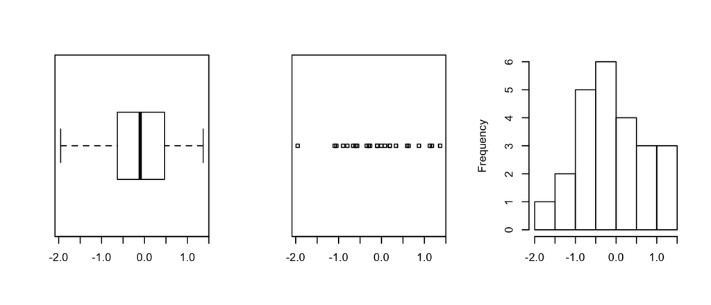

### Paired Samples t Test

When there is just 1 sample of differences to display, a boxplot, dot plot, or histogram can be used. (An overzealous student may also show a custom chart depicting the actual differences between the two pairs of points.)

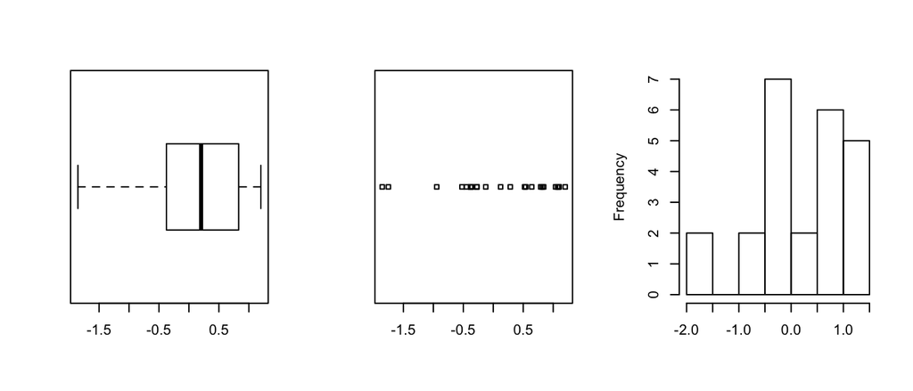

### Independent Samples t Test

When there are two samples, a dot plot or boxplot is best practice.

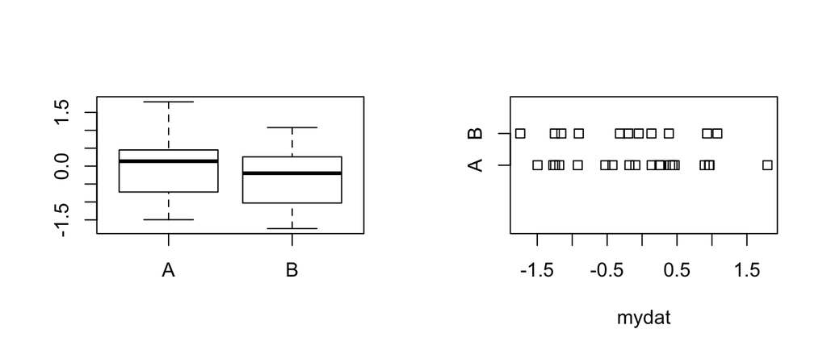

### Interpretation Section

The student should only make claims about things that were tested with p-values in their Analysis section. They can hypothesize about new ideas, but should only make statements and claims about things that were directly tested in their analysis.

### Presentation Section

The document should flow from beginning to end, be easy to follow, look nice, and be interesting.